# Lab9

## Exercise: Making a distribution of sample means

Step 3b: calculate the same summaries as above for each sample

```r
res<-list() #create empty list to put the summaries in
for(i in 1:length(samps)){ #for loop for each elements in the samps list
  res[[i]]<- samps[[i]] %>%
   summarise(
    MeanLength = mean(size),
    MedianLength = median(size),
    SDLength = sd(size),
    IQR = IQR(size)
)
  print(i) #print each iteration
}
```

```
## [1] 1
## [1] 2
## [1] 3
## [1] 4
## [1] 5
## [1] 6
## [1] 7
## [1] 8
## [1] 9
## [1] 10
```

```r
res
```

```
## [[1]]
## # A tibble: 1 × 4
##   MeanLength MedianLength SDLength   IQR
##        <dbl>        <dbl>    <dbl> <dbl>
## 1      3479.        2978.    2578. 2636.
##
## [[2]]
## # A tibble: 1 × 4
##   MeanLength MedianLength SDLength   IQR
##        <dbl>        <dbl>    <dbl> <dbl>
## 1      3532.         2850    2505. 2883.
##
## [[3]]
## # A tibble: 1 × 4
##   MeanLength MedianLength SDLength   IQR
##        <dbl>        <dbl>    <dbl> <dbl>
## 1      3607.         2724    2653.  3116
##
## [[4]]
## # A tibble: 1 × 4
##   MeanLength MedianLength SDLength   IQR
##        <dbl>        <dbl>    <dbl> <dbl>
## 1      3341.         2522    2424.  3294
##
## [[5]]
## # A tibble: 1 × 4
##   MeanLength MedianLength SDLength   IQR
##        <dbl>        <dbl>    <dbl> <dbl>
## 1      3766.         3272    2933. 2828.
##
## [[6]]
## # A tibble: 1 × 4
##   MeanLength MedianLength SDLength   IQR
##        <dbl>        <dbl>    <dbl> <dbl>
## 1      3729.        3202.    2761.  3278
##
## [[7]]
## # A tibble: 1 × 4
##   MeanLength MedianLength SDLength   IQR
##        <dbl>        <dbl>    <dbl> <dbl>
## 1      3513.         3265    2337.  2795
##
## [[8]]
## # A tibble: 1 × 4
##   MeanLength MedianLength SDLength   IQR
##        <dbl>        <dbl>    <dbl> <dbl>
## 1      3147.         2876    1974. 2544.
##
## [[9]]
## # A tibble: 1 × 4
##   MeanLength MedianLength SDLength   IQR
##        <dbl>        <dbl>    <dbl> <dbl>
## 1      3496.        2454.    2866. 2826.
##
## [[10]]
## # A tibble: 1 × 4
##   MeanLength MedianLength SDLength   IQR
##        <dbl>        <dbl>    <dbl> <dbl>
## 1      3280.         2581    2242. 2591.
```

## Exercise: Making a distribution of sample means

Can we do it all in one go?

```r
x<-seq(1:10) #create a vector with numbers from 1 to 10000
#create tibble with the columns produced by our summaries
#dummy tibble
resamps<-tibble(MeanLength=NA, MedianLength=NA, SDLength=NA, IQR=NA)
for(i in x){ #for loop
  temp<-human_genes %>% #assign to temp object
    sample_n(size=100, replace=F) %>% #sample
    summarise( # summaries
    MeanLength = mean(size),
    MedianLength = median(size),
    SDLength = sd(size),
    IQR = IQR(size)
    )
  resamps<-bind_rows(resamps, temp) #add new row to tibble
  print(i) #print each iteration
}
```

```
## [1] 1
## [1] 2
## [1] 3
## [1] 4
## [1] 5
## [1] 6
## [1] 7
## [1] 8
## [1] 9
## [1] 10
```

## Exercise: Making a distribution of sample means

```r
#the first row has NAs. we can easily get rid of it.

resamps<-na.omit(resamps) #remove lines with NA
resamps
```

```
## # A tibble: 10 × 4
##    MeanLength MedianLength SDLength   IQR
##         <dbl>        <dbl>    <dbl> <dbl>
##  1      3269.        2716.    2187. 2952.
##  2      3772.        3020.    2489. 3320.
##  3      3704.        2936     3283. 2936.
##  4      3945.        3260     2664. 2564.
##  5      3506.        2828     2611. 3014.
##  6      4064.        2756.    4847. 3218.
##  7      3220.        2633     2404. 2863
##  8      3362.        2709     2550. 2629.
##  9      3377.        2869     2132. 3260.
## 10      3437.        2380     3193. 2570.
```

## Exercise: Making a distribution of sample means

Step 3c: if everything works, switch to 10,000

```r
nsamps=10000
resamps<-tibble(MeanLength=NA, MedianLength=NA, SDLength=NA, IQR=NA)
for(i in 1:nsamps){ #for loop
  temp<-human_genes %>% #assign to temp object
    sample_n(size=100, replace=F) %>% #sample
    summarise( # summaries
    MeanLength = mean(size),
    MedianLength = median(size),
    SDLength = sd(size),
    IQR = IQR(size)
    )
  resamps<-bind_rows(resamps, temp) #add new row to tibble
  if(i %in%  seq(from=1, to=nsamps, by=500)){
  print(i) #print 1st,501st,1001st etc iterations
  }
}
```

## Exercise: Making a distribution of sample means

Make a function that calculates all the summaries

```r
library(infer)
#samps
nsamps<-10 #once this works, switch to 10,000
reps<-rep_sample_n(human_genes, size=100, replace=FALSE, reps=nsamps) %>%
  group_by(replicate) %>%
  summarise( # summaries
  MeanLength = mean(size),
  MedianLength = median(size),
  SDLength = sd(size),
  IQR = IQR(size)
) %>%
  ungroup
```

## Exercise: Making a distribution of sample means

Step 4: Plot the sampling distribution with ggplot

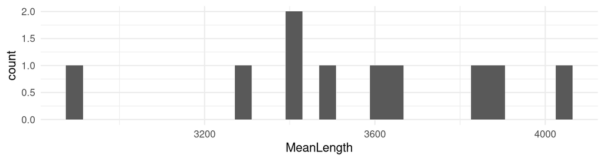

```r
library(ggplot2)
#rerun previous code with nsamps=10000
ggplot(reps, aes(x=MeanLength)) +
  geom_histogram() +
  theme_minimal()
```

## Exercise: Making a distribution of sample means

Final step: Obtain the grand mean (mean of sample means) and the standard deviation of the sample means and: compare with the population mean; calculate SEM using the distribution and the formula and compare.

```r
#Try it!
```

## Exercises!

- Binomial hypothesis testing: `lab9_ex1.Rmd`
- Loops & Conditional Statements: Exercises in `lab9_ex2.Rmd`.